# Assignment - Week 4

7 March 2018

## Background

This presentation is created as part of the assessment for the Course Project: Shiny Application and Reproducible Pitch.

Following the instructions:

- 5 slides to pitch our idea done in Slidify or Rstudio Presenter
- Your presentation pushed to github or Rpubs
- A link to your github or Rpubs presentation pasted into the provided text box

## Data

This famous (Fisher's or Anderson's) iris data set gives the measurements in centimeters of the variables sepal length and width and petal length and width, respectively, for 50 flowers from each of 3 species of iris. The species are Iris setosa, versicolor, and virginica.

iris is a data frame with 150 cases (rows) and 5 variables (columns) named Sepal.Length, Sepal.Width, Petal.Length, Petal.Width, and Species.

```r
head(iris, 3)
```

```
##   Sepal.Length Sepal.Width Petal.Length Petal.Width Species
## 1          5.1         3.5          1.4         0.2  setosa
## 2          4.9         3.0          1.4         0.2  setosa
## 3          4.7         3.2          1.3         0.2  setosa
```

## Linear regression plot

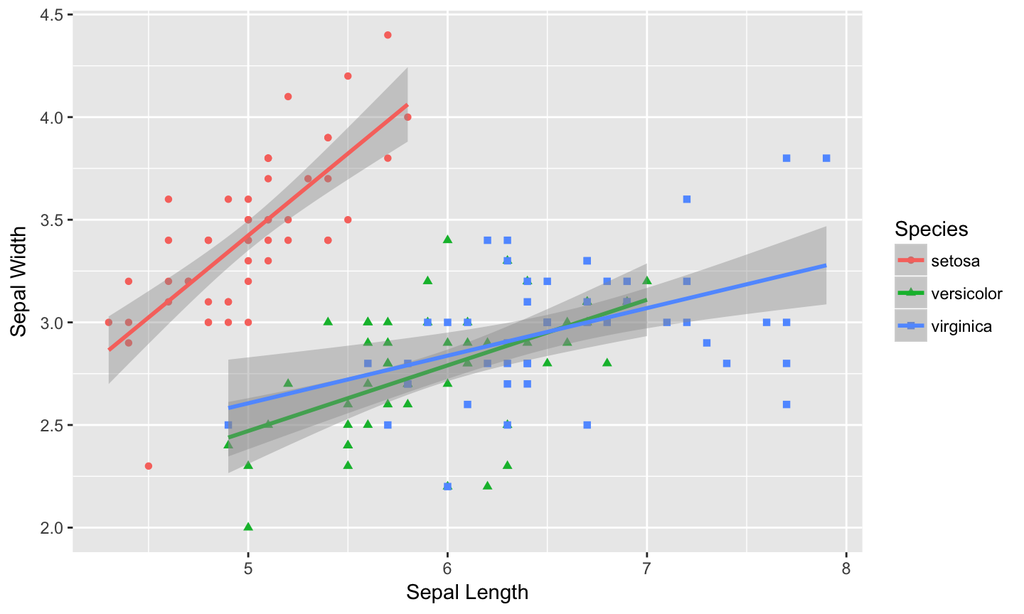

## Links

My shiny app can be found here: https://msbazely.shinyapps.io/project/

The app alllows the user to:

- Greeting: Enter user name
- Plot tab: select X and Y variables to be displayed

GitHub repo can be found here: https://github.com/PukkaPad/DataScienceR/tree/master/09_DevelopingDataProducts/Project

This presentation can be found here: http://rpubs.com/PukkaPad/dataprod